# Identifying fake news in two languages

Natural Language Processing

This project compares two machine learning models (Logistic Regression and Passive-agressive)to detect fake news in two languages: English and Spanish.

Maria Fernanda Ortega https://github.com/MariaFernandaOrtega/ML-Project , Radwa Abdelsalam  
2022-12-07

[figure not shown]

## Abstract

One of the main challenges in the digital era is the difficulty of evaluating the reliability of information sources. Fake news have been a central theme of this topic given its proliferation and detrimental effect on society. The proposed method in the project revolves around comparing two base line models and assessing the performance on fake news data set obtained from ”ISOT Fake News” database, which is made available by the University of Victoria, Canada. The motivation of the project is provide machine learning model that can be used as embedded baseline for fake news classification model for a user friendly interface offered to the citizen. In addition to using English language dataset as an initial phase of the project for testing supervised machine learning algorithms, Logistic Regression and Passive Aggressive Classifier performance, the project also used Spanish language fake news data set that was augmented by data web scrapped from Spanish news websites. The English and non-English language approach was used to compare the performance of both models. Across language results show lower performance level of Logistic Regression in comparison to Passive Aggressive Classifier. Performance metrics used to measure performance are Accuracy rate and F1 score in addition to confusion matrix and cross validation to ensure the absence of bias during the training and fitting phase.

## Introduction / Background

The growing significance of fake news topic is parallel with the rise of prominence of social media as a source of news for the public. The salience of addressing the issue of fake news lies in the susceptibility of human beings to become victims of fake news. Fake news pertains a great impact due to the spread of dissemination and the dangers it poses. The inability to detect falsehood from truth endangers democracy and can be regarded as a stepping stone for authoritarian regimes to attain power (McIntyre 2021). Fake news can undermine authority or even swing elections results. According to (Oliveira et al. 2021), although fake news content detection is mainly the responsibility of the social media provider, improving the online information ecosystem also falls under the mandate of the digital policy makers, scientific community and management and society.

## Related Work

The search for solutions to stop this topic has motivated the development of software mechanisms capable of recognizing fake news. For instance, (Mahir et al. 2019), proposed a model to identify forged news messages from Twitter posts by using machine learning classifiers. The research concluded that Support Vector Machine (SVM) and Naïve Bayes outperform the other algorithms studied (Logistic Regression and Recurrent Neural Network). A different approach is followed by (Bajpai and Kumar Tripathi 2021). They state that as the data gets enormously large, the algorithm at hand becomes less effective. Therefore, for their research, the authors selected a model through implementing two highly efficient algorithms, Multinomial Naïve Bayes and Passive Aggressive Classifier. The accuracy of the model was 94.5 percent using the Multinomial Naive Bayes method, and with the Passive Aggressive the accuracy increased further to 99.5 percent. In a more recent study, (Probierz, Stefański, and Kozak 2021), argued that the detection of fake news can be effective based on title itself, without the need to analyze the entire text, which significantly reduces the time of decision-making. Their model is based on a natural language processing (NLP) and machine learning algorithms for classification (Support Vector Machine, Classification and Regression Trees, the Boosting Method, the Bagging Approach, and the Random Forests). When analyzing the news titles, they conclude that the best results for all metrics used are obtained when the SVM algorithm is used (Accuracy 0.9419).

## Proposed Method

For the purpose of reducing causal collocation in a large corpus, tokenization method is adopted in the data pre-processing phase. Given the large amount of data, with particular regards to the text in the news, pattern detection by the algorithm would perform significantly higher with linguistic selection of important tokens. Following breaking the data into substrings tokens, data cleaning method applied included removing stop-words for dimensionality reduction of word space (Vijayarani et al. 2015). All numeric data in the title and the text are removed as well. As a second step of dimensionality reduction, we applied stemming using corpus based stemmer to remove unnecessary variation of the same word reduce noise in the data. The final stage of pre-processing applied is Term Frequency-Inverse Document Frequency (TF-IDF) for feature extraction (Gupta and Meel 2021). Through counting the token’s frequency and assigning weights in an inverse manner to pinpoint the key identifying tokens. The TF-IDF vectorization is performed in the same pipeline of the algorithms for both datasets.

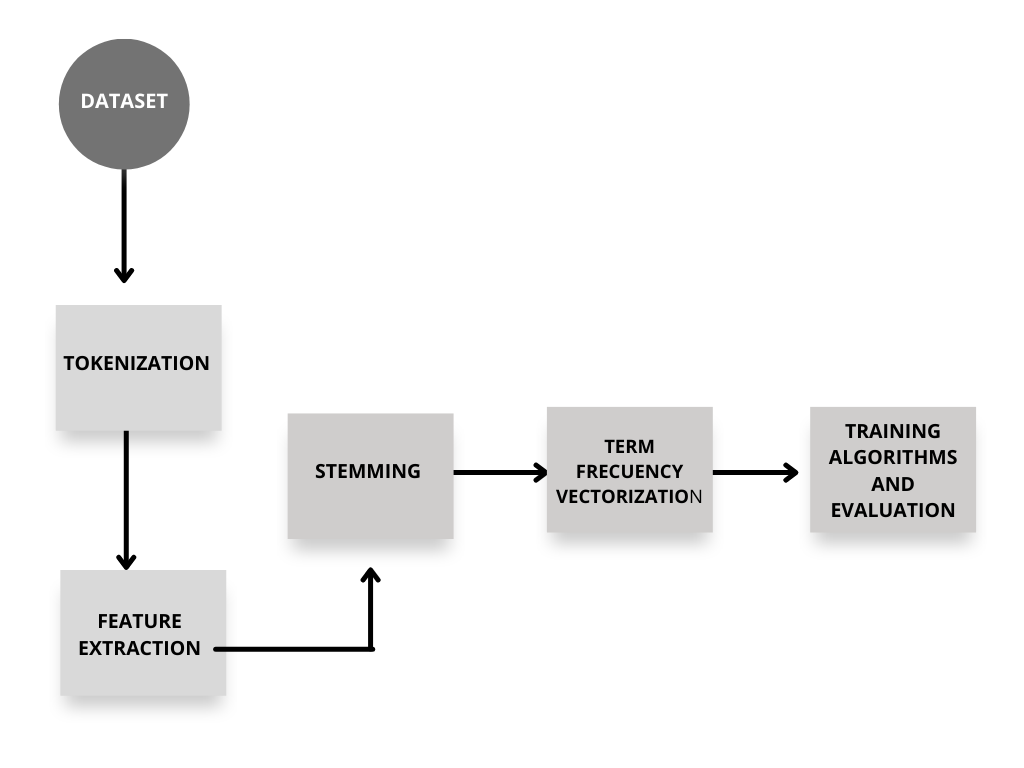

Figure 1: Pre-Processing Diagram

The project’s main pillar methodological approach is classification, thus the models used are from the supervised machine learning algorithm branch. Two classification algorithms, Logistic Regression (LR) and Passive Aggressive Classifier (PAC), are implemented as methods for fake news detection.

## Experiments

**Data**: To evaluate the effectiveness of the selected machine learning algorithms, this project uses the “ISOT Fake News Dataset.”The data was collected from real world sources and contains more than 12,600 truthful articles from Reuters.com (news website) and more than 12,600 articles from different fake news outlet resources (sites were flagged as unreliable by Politifact.com). The dataset is approximately balanced between fake (52.3%) and real (47.7%). Each article contains the following information: article title, text, type, and the date the article was published on. The dataset contains different types of news, most focused on political and global issues.

For the second part of the project, we analysed a database of fake and real news in Spanish. The information was collected from two sources. First, we used the database shared by the Secretariat of Higher Education, Science, Technology and Innovation of the government of Ecuador, which contains 538 news articles from 2019, of which 57% are legitimate news from reputable newspapers and 43% are fake news coming from websites reported for spreading fake news in Ecuador (the government does not specify the names of these websites nor the newspapers). Each article contains the following information: article text, news type (legit/fake), and the date the article was published on. In order to make our news source more diverse and complex, 104 articles from reliable online newspapers (Milenio and Aristegui Noticias) were added to this database. Thus, the final Spanish database has 35% fake news and 65% real news.

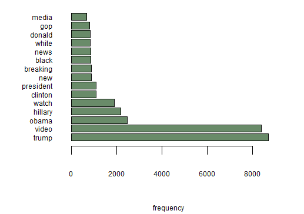

Figure 2: Tokens frequency -fake news (English)

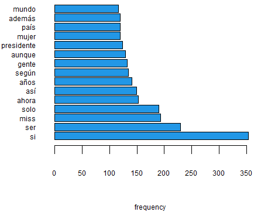

Figure 3: Tokens frequency -fake news (Spanish)

**Software**: For this project, Python was used as the programming language. Specifically, Pandas, Numpy and Matplotlib libraries were used for data pre-processing and visualisation. The Natural Language Toolkit (NLTK) was used for text tokenisation, “stop word” removal and stemming process. Finally, the Scikit-learn library was utilized to train and test the models.

**Experimental details**: For this project, two experiments have been carried out. The first one analyses the database with news in English and compares the results of the evaluation metrics on the title and the text of the news. Furthermore, the dataset was divided into training data (70%) and test data (30%). The selected models were set with default parameters.

For the second experiment, a new database with news in Spanish was selected to evaluate the quality of the models, Logistic Regression and Passive Aggressive, in detecting fake news using the text of the news, and compare it with the results obtained in the first experiment. In this case, the training data is 80% and the test data is 20%. First, the selected classifiers were set with the default parameters, and then a hyper-parameter tuning was performed for the model that obtained the lowest result (Logistic Regression).

**Results Experiment 1**: The results related to this experiment can be divided into two levels of evaluation: data analysis time and classification quality in predicting fake news.

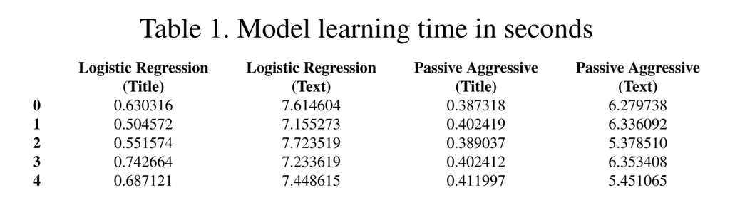

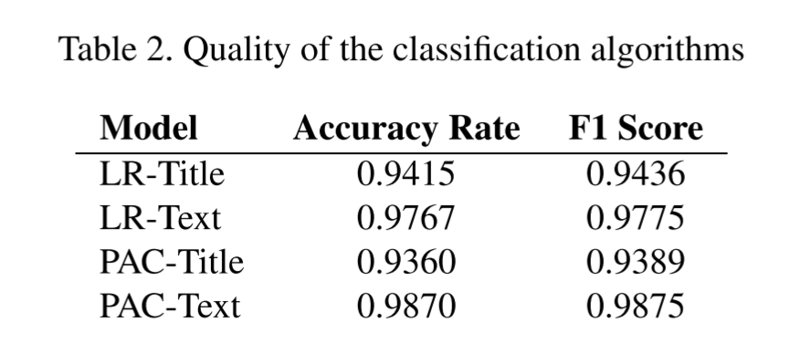

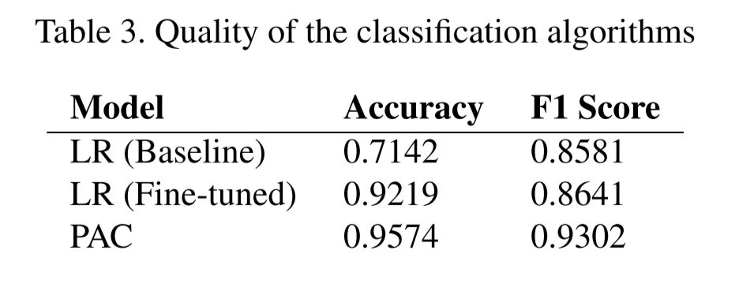

Furthermore, table 4 shows a comparison of the F1 Score between the articles in English (first experiment) and the news in Spanish. The results are significantly better when implementing the models on the English database.

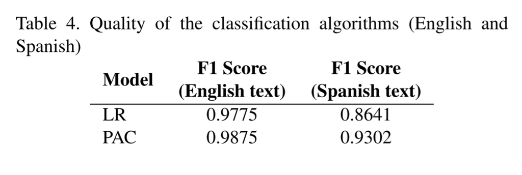

**Comment on quantitative results (Experiment 2)** : The objective of this experiment was to compare the quality of machine learning models (Passive Aggressive and Logistic Regression) to detect fake news with non-English text. The first hypothesis for this phase was that we would observe a decrease in the Accuracy rate and F1 Score for both models because, unlike the English database, in this experiment the news come from different sources and cover different topics. Furthermore, we added 104 true and recent articles to try to simulate a scenario more similar to the real world, where there is no uniform division of true and false news. From table 4 we conclude that this hypothesis was true.

The second assumption made was that the passive-aggressive classifier would outperform the logistic regression model, since the existing literature shows a preference for using this classifier for fake news prediction. In table 3 we can observe that even after optimising the hyper-parameters for the logistic regression model, the passive-aggressive algorithm does a better job in categorising fake and true news. It should be noted, however, that a weakness of the second database (news in Spanish) is that it does not contain such a large number of articles, so it is very likely that if the number is increased, this hypothesis would no longer hold true and other machine learning models would need to be tested.

## Conclusion(s)

Logistic Regression and Passive Aggressive models show high level of performance on text and title English dataset. The models’ performance is higher for the text in comparison to the title dataset. The balance of the data, in terms of true and fake, plays an important role in the performance of the models in terms of both accuracy and F1-score. Applying the two models on non-English language dataset showed lower performance for both models, albeit observable lower value for logistic regression. Thus, it can be argued that logistic regression has limitations when applied to non-English language dataset. On the other hand, given that the dataset structure has a lower balance ratio between fake and true data, the model training might have been affecting by such aspect.

The greater the number of the sample used in research the more critical insight on the performance of models on non-English dataset would be more evident. There is a debate in the literature on whether non-English language should be translated into English prior to implementing the model or using the native language directly into the models as a best practice (Zervopoulos et al. 2022). Future research can look into stylometric features to provide classification and improved the identification of fake news in terms of satire for example (Abonizio et al. 2020). Such a result can be research to link specific tokens its effect on public opinion.

## Acknowledgments

We thank the University of Victoria and the Secretariat of Higher Education, Science, Technology and Innovation of Ecuador for providing the datasets we used to evaluate the performance of the models (Passive-aggressive and logistic regression) in differentiating fake from real news.

Abonizio, Hugo Queiroz, Janaina Ignacio de Morais, Gabriel Marques Tavares, and Sylvio Barbon Junior. 2020. “Language-Independent Fake News Detection: English, Portuguese, and Spanish Mutual Features.” *Future Internet* 12 (5): 87.

Bajpai, Abhyudya, and Amit Kumar Tripathi. 2021. “Detection of Fake News Using Binary Classification.” https://www.ijser.in/archives/v9i5/SE21502152759.pdf.

Gupta, Saloni, and Priyanka Meel. 2021. “Fake News Detection Using Passive-Aggressive Classifier.” In *Inventive Communication and Computational Technologies*, 155–64. Springer.

Mahir, Ehesas Mia, Saima Akhter, Mohammad Rezwanul Huq, et al. 2019. “Detecting Fake News Using Machine Learning and Deep Learning Algorithms.” In *2019 7th International Conference on Smart Computing & Communications (ICSCC)*, 1–5. IEEE.

McIntyre, Lee. 2021. “The Hidden Dangers of Fake News in Post-Truth Politics.” *Revue Internationale de Philosophie*, no. 3: 113–24.

Mhatre, Sanket, and Akhil Masurkar. 2021. “A Hybrid Method for Fake News Detection Using Cosine Similarity Scores.” In *2021 International Conference on Communication Information and Computing Technology (ICCICT)*, 1–6. IEEE.

Oliveira, Nicollas R de, Pedro S Pisa, Martin Andreoni Lopez, Dianne Scherly V de Medeiros, and Diogo MF Mattos. 2021. “Identifying Fake News on Social Networks Based on Natural Language Processing: Trends and Challenges.” *Information* 12 (1): 38.

Probierz, Barbara, Piotr Stefański, and Jan Kozak. 2021. “Rapid Detection of Fake News Based on Machine Learning Methods.” *Procedia Computer Science* 192: 2893–2902.

Vijayarani, S, Ms J Ilamathi, Ms Nithya, et al. 2015. “Preprocessing Techniques for Text Mining-an Overview.” *International Journal of Computer Science & Communication Networks* 5 (1): 7–16.

Vivas, Jorge, Boris Kogan, Sofı́a Romanelli, Francisco Lizarralde, and Luis Corda. 2020. “A Cross-Linguistic Comparison of Spanish and English Semantic Norms: Looking at Core Features.” *Applied Psycholinguistics* 41 (2): 285–97.

Zervopoulos, Alexandros, Aikaterini Georgia Alvanou, Konstantinos Bezas, Asterios Papamichail, Manolis Maragoudakis, and Katia Kermanidis. 2022. “Deep Learning for Fake News Detection on Twitter Regarding the 2019 Hong Kong Protests.” *Neural Computing and Applications* 34 (2): 969–82.